# 0127_0204

Eren Kafadar

2024-01-27

# Thoughts on this week

Jenna sent out manual QC data, I should take a look at this ASAP. This week I also have my proposal with Specific Aims due on Friday Feb 2nd. For the data I would like to run some gamlss for sure this week. Even if it is super preliminary and on a very small amount of data.

#Aaron mtg 01/29 Would be helpful to look at the scans for some of the younger low QC scans. Look at some 0.6 - 0.65 scans as well (are they failing or not) Q - Synthseg trained on babies? MRI looks different? Could segmentation be better for T2 images due to tissue density differences? Look at whether the QC min is dominated by any of the specific structures, or generally spread out? $\checkmark$

Synthseg output can assess regional specificity. Organized around the SA axis?

ABCD - connectivity question? There is connectivity data. Think of it as an imaging genetics dataset.

This is the script from Jenna’s github that would be a helpful place to start to build gamlss models. There should also be Jakob’s scripts that are more complicated but provide more flexibility (this is my understanding) in choosing a model. https://github.com/jmschabdach/mpr_analysis/blob/develop/r/build_your_own_growth_chart.R

Notes on Jenna Code - FreeSurfer model includes SurfaceHoles variable in model, not applicable in SynthSeg output. - logAge: numeric type with log(post conception age in days, base=10). In (1), we use a conversion factor of 325.25 days/year and a post conception offset of 280 days if post conception age is not available.

# Play

## Load Data

Data Jenna sent is in 3 folders by release date There are 3 files in each folder - qc scores csv % synthseg volumes csv – 2155 unique subject_ids, and 11267 unique data points (subject + age at scan?) - participants tsv – 2173 total data

Put all the data together from three releases and merge the qc scores, volumes, and participant data Save this full dataset ###Load all csv data and merge

saved SLIP_combined_011923.csv with 11267 rows and 137 variables

###Load full data, new df for data with GA

## Gestational Age

Get the data with GA separated.

Sex for those with GA data 1823 Male 1342 Female

VPM 143 LPM 566 Term 2456

Boxplot of preterm categories

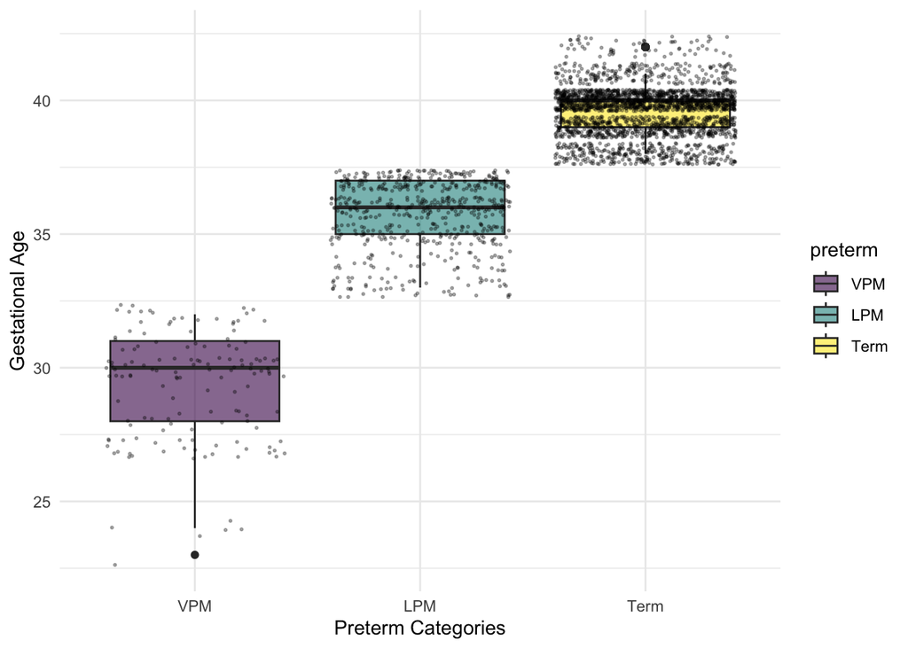

```
##   preterm    n
## 1     VPM  143
## 2     LPM  566
## 3    Term 2456
```

## QC Scores

Get minQC column

###General QC notes synthseg QC scores is like a predicted dice coef, based on trained models, only trained for some values. this QC might not be good enough, might have to go back and do some QC Synthseg is hierarchical, ie finds cortex and then finds regions between them **Confirm with Jakob, 0.65 across every single one (all should be above 0.65 within a sample) Might need to do some sensitivity analyses.**

For a subset of these there should be manual QC done. What about the relationship between the synthseg QC values vs manual QC values in that subset? Might be useful in terms of convincing synthseg automated QC could be sufficient.

After the centile scores, see whether the centile score is related to QC and could include the QC score in the model (down the line, to control for it if it is affecting the centile score)

- Make a plot of the minimum QC score for each subject distribution. Shape of the distribution. Look at the distribution for the cut-off (hopefully around 0.65).$\checkmark$
- QC score against age, and against gestational age (any bias here?).$\checkmark$
- Plot GA availability with recency of scan (more likely to have GA?). *I don’t think I have data for when the scan took place*

Expectation: A higher proportion of data would have GA if its for people under < 5, with only more recent scans Look at QC scores for variables which include QC scores: * general WM * general GM * general CSF * cerebellum * brainstem * thalamus * putamen.pallidum * hippocampus.amygdala

###Correlations of QC with age, GA

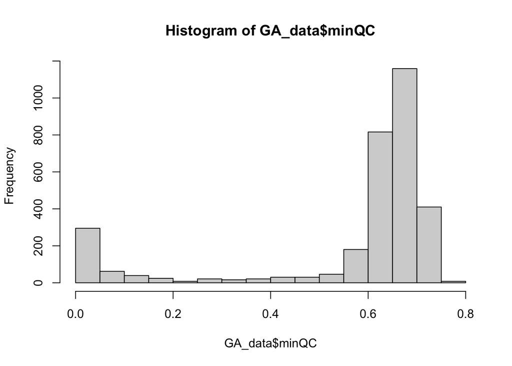

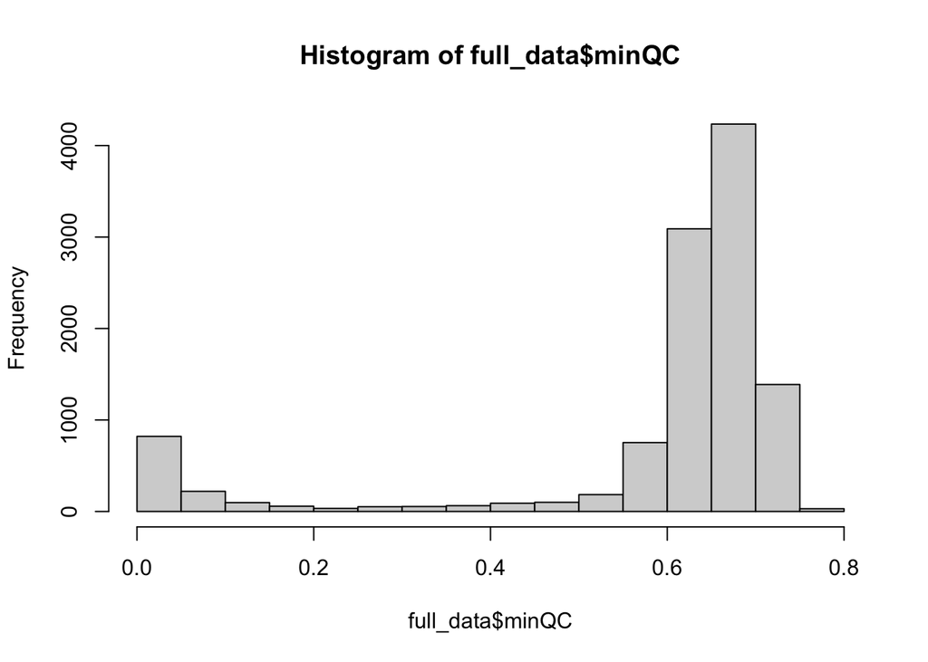

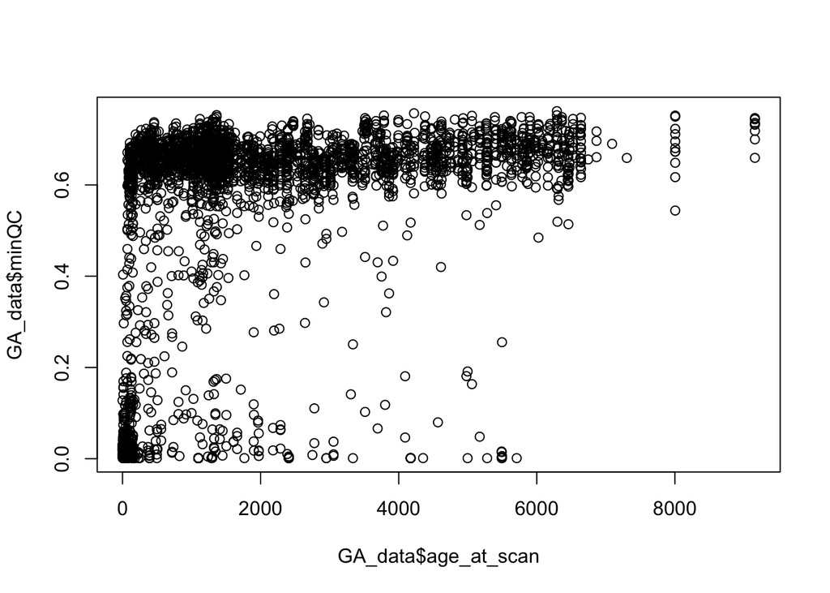

```
##
##  Pearson's product-moment correlation
##
## data:  GA_data$age_at_scan and GA_data$minQC
## t = 19.788, df = 3163, p-value < 2.2e-16
## alternative hypothesis: true correlation is not equal to 0
## 95 percent confidence interval:
##  0.3005419 0.3625560
## sample estimates:
##       cor
## 0.3319075
```

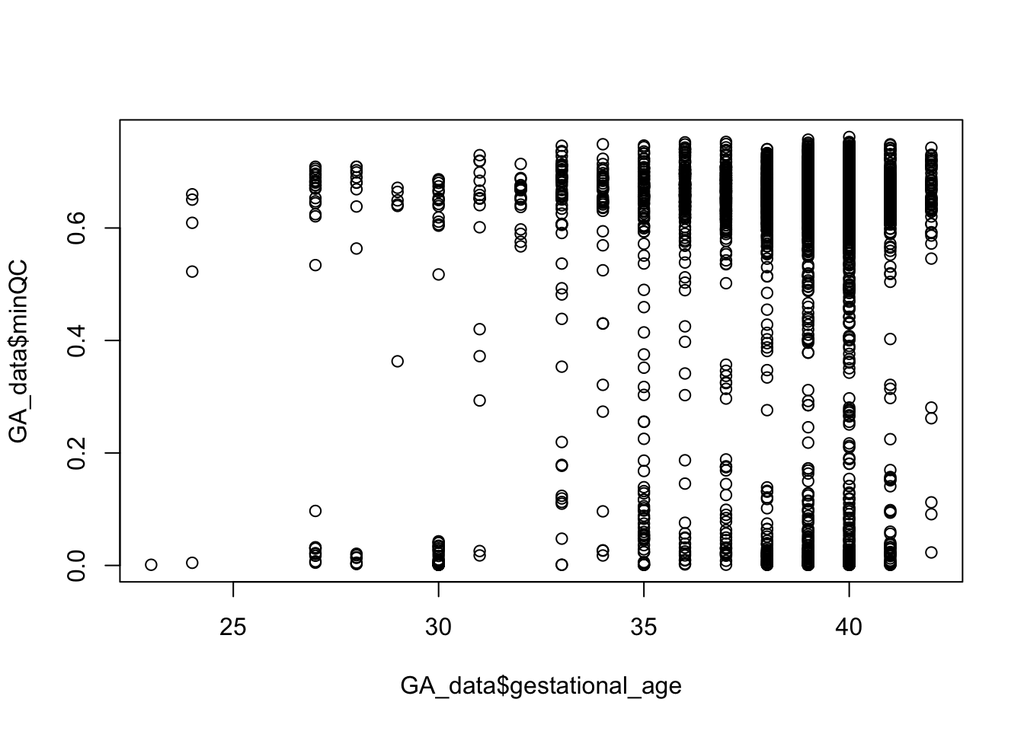

```
##
##  Pearson's product-moment correlation
##
## data:  GA_data$gestational_age and GA_data$minQC
## t = 8.7985, df = 3163, p-value < 2.2e-16
## alternative hypothesis: true correlation is not equal to 0
## 95 percent confidence interval:
##  0.1203708 0.1883902
## sample estimates:
##       cor
## 0.1545636
```

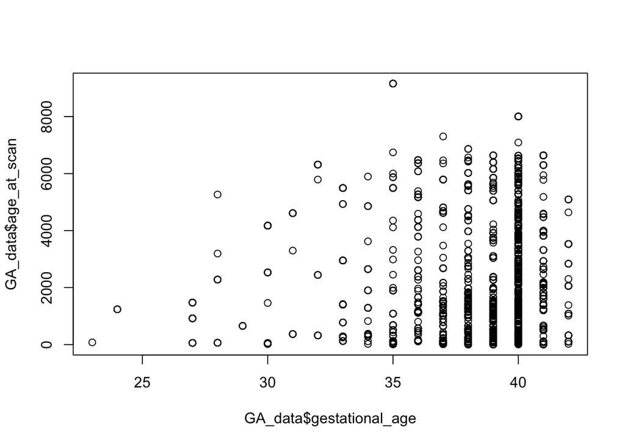

```
##
##  Pearson's product-moment correlation
##
## data:  GA_data$gestational_age and GA_data$age_at_scan
## t = 3.3721, df = 3163, p-value = 0.0007549
## alternative hypothesis: true correlation is not equal to 0
## 95 percent confidence interval:
##  0.02506244 0.09449525
## sample estimates:
##        cor
## 0.05985124
```

```
##
##  VPM  LPM Term
##  143  566 2456
```

```
##
##  VPM  LPM Term
##   80  409 1905
```

```
##
##   23   24   27   28   29   30   31   32   33   34   35   36   37   38   39   40
##    1    5   29   17    6   47   17   21   54   44  115  164  189  326  630 1230
##   41   42
##  210   60
```

```
##
##  24  27  28  29  30  31  32  33  34  35  36  37  38  39  40  41  42
##   3  18   9   5  16  12  17  38  33  65 133 140 240 475 985 155  50
```

**0.65** 1579/3165 have QC > 0.65 ~ 49% of the total # of obs **0.60** 2394/3165 have QC > 0.60 ~ 75% of the total # of obs 80/143 VPM – proportionally more VPM QC-ed out. 409/566 1905/2456

###Is minQC Driven by any specific region? - seem to be that CSF ang GM have smaller QC values than other regions full data

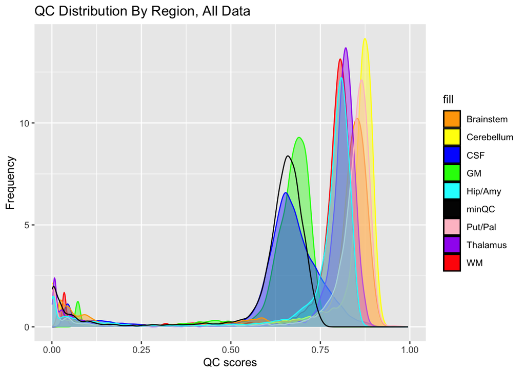

GA data

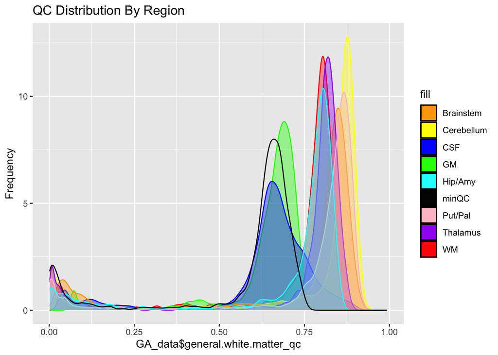

###Manual QC and Auto QC similarity? SLIP paper used average QC >= 1.0 Odds Ratio? For the full dataset

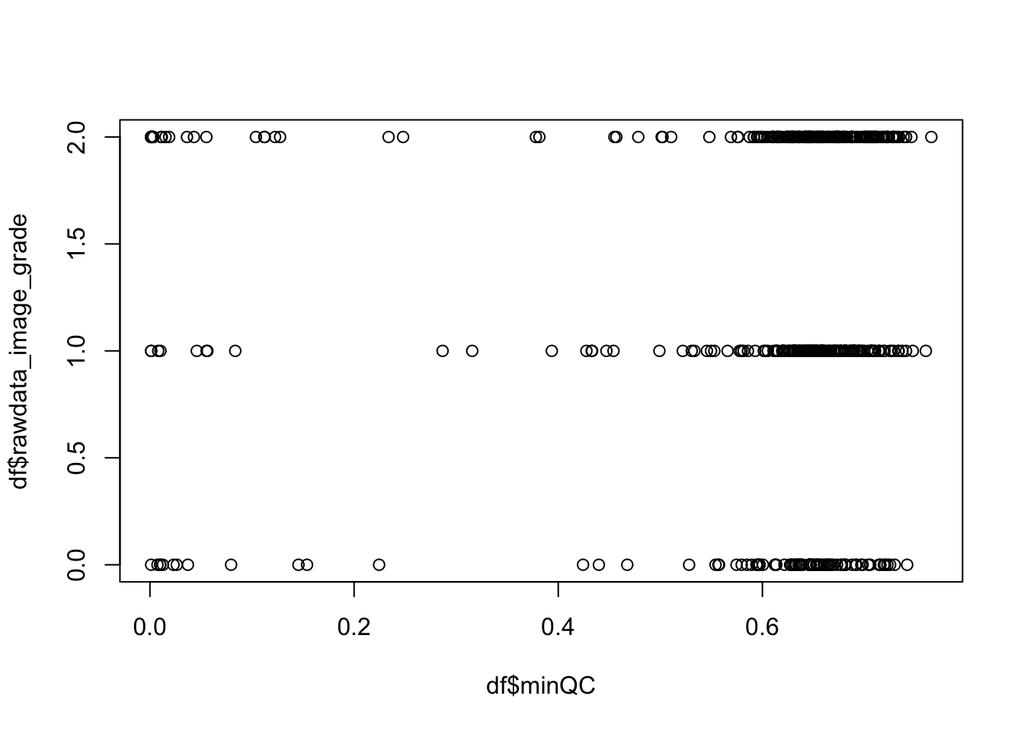

```
##
##  Pearson's product-moment correlation
##
## data:  df$minQC and df$rawdata_image_grade
## t = 0.34215, df = 470, p-value = 0.7324
## alternative hypothesis: true correlation is not equal to 0
## 95 percent confidence interval:
##  -0.07458228  0.10588602
## sample estimates:
##        cor
## 0.01578039
```

```
## [1] 380
```

```
## [1] 227
```

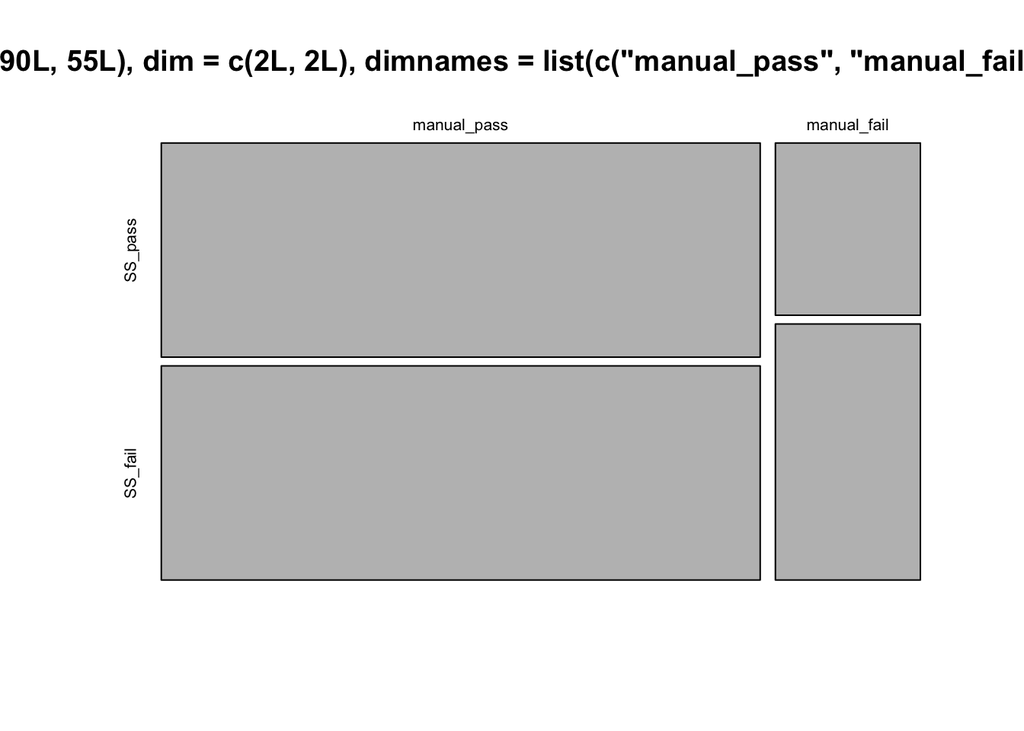

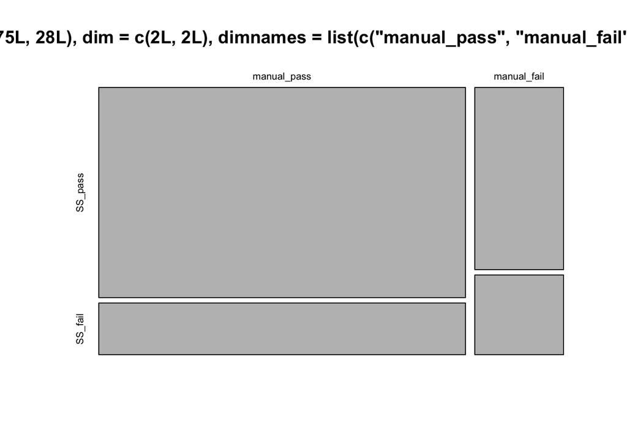

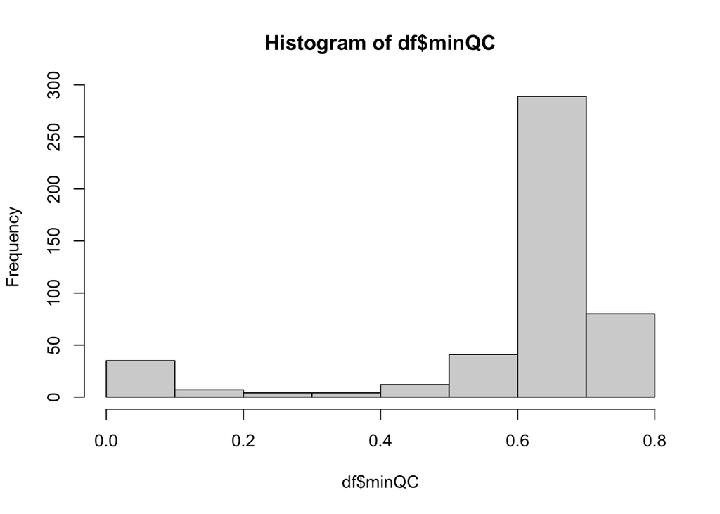

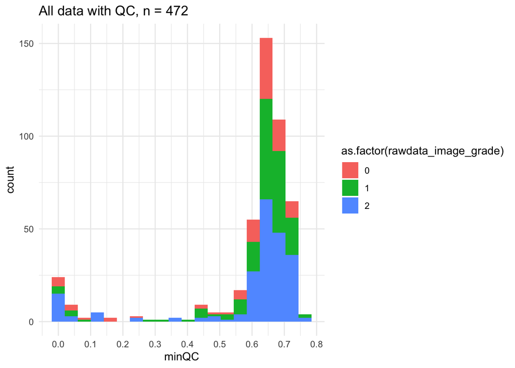

For the GA data odds ratio of being high QC under SS when high QC under manual is 2.43 (with SS value at 0.65) 2.35 with SS value at 0.6 80/101 pass manual QC, 56/101 pass SS auto QC (at 0.65)

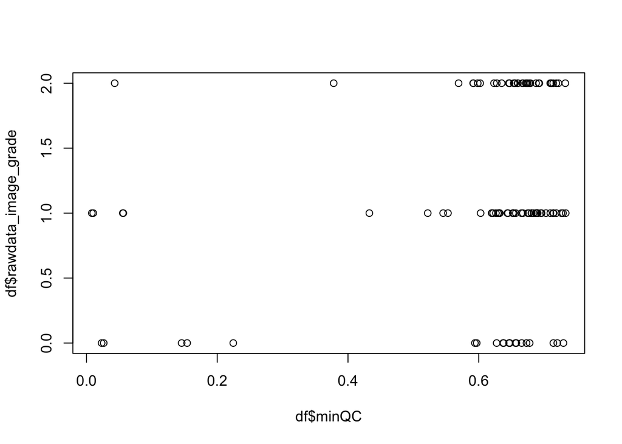

```
##
##  Pearson's product-moment correlation
##
## data:  df$minQC and df$rawdata_image_grade
## t = 2.1108, df = 99, p-value = 0.03731
## alternative hypothesis: true correlation is not equal to 0
## 95 percent confidence interval:
##  0.01259467 0.38725599
## sample estimates:
##       cor
## 0.2075231
```

```
## [1] 80
```

```
## [1] 56
```

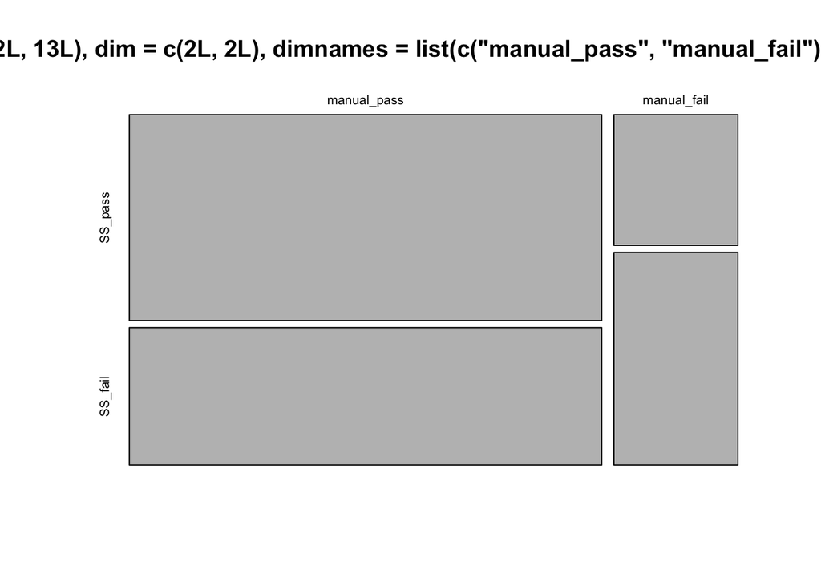

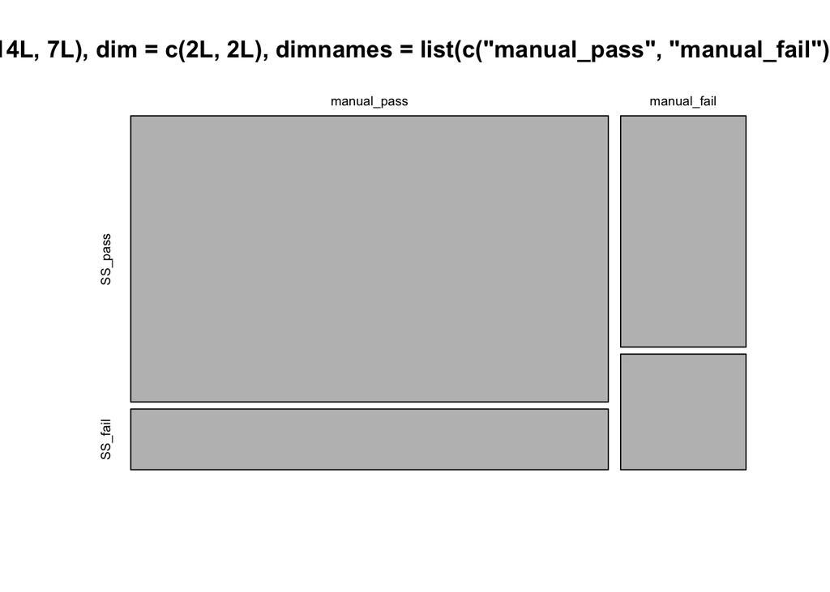

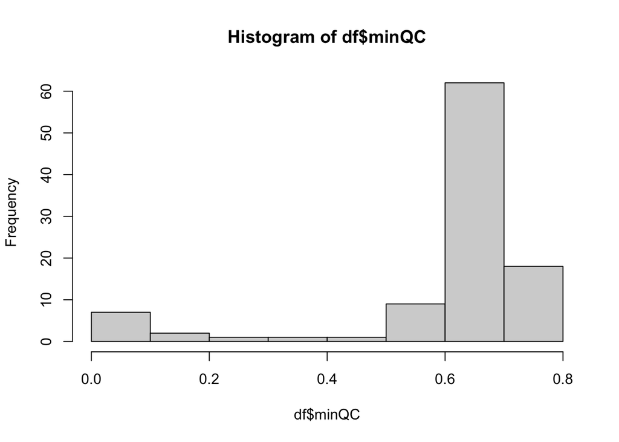

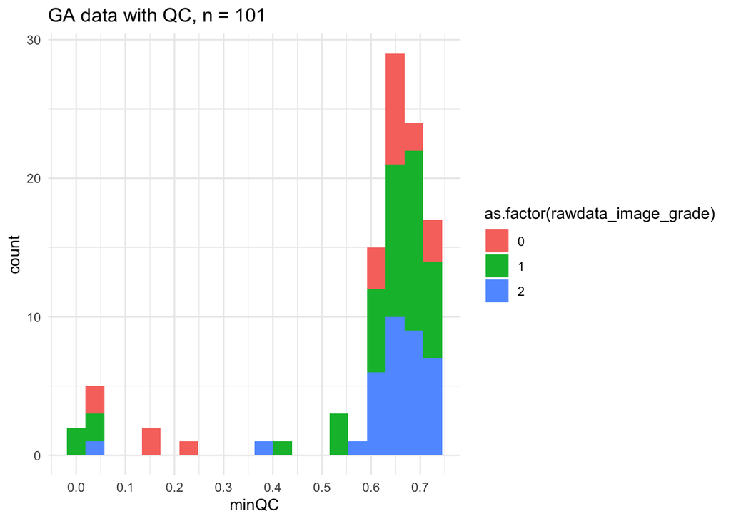

*** Logistic regression to predict manual QC value from SS auto QC - minQC not a significant predictor of “pass” status in manual QC

```
##
## Call:
## glm(formula = manual_QC_pass ~ minQC, family = "binomial", data = df)
##
## Coefficients:
##             Estimate Std. Error z value Pr(>|z|)
## (Intercept)   0.9360     0.3445   2.717  0.00659 **
## minQC         0.8293     0.5658   1.466  0.14274
## ---
## Signif. codes:  0 '***' 0.001 '**' 0.01 '*' 0.05 '.' 0.1 ' ' 1
##
## (Dispersion parameter for binomial family taken to be 1)
##
##     Null deviance: 465.65  on 471  degrees of freedom
## Residual deviance: 463.62  on 470  degrees of freedom
## AIC: 467.62
##
## Number of Fisher Scoring iterations: 4
```

Notes after impromptu meeting with Jenna on 01/31 on QC stuff GM/CSF/WM – could just be sums? Is QC value an average of these sums? Doesn’t seem likely given the distributions. There is specific QC ratings for the manual ratings in the respublika folder for the SLIP radiology paper. This could be useful to look at specific ratings of the images. The specific images used to rate are also in this folder I think

###Looking at Individual Scans Take a look at individual scans that have - borderline auto QC 0.6/0.65 - mismatched auto & manual QC - mid-low auto QC 0.2-0.4 Look at about ~2-3 scans from each category in fsl viewer on Respublika Screenshot them for google slides. Choosing the scans to be looked at:

```
## # A tibble: 1 × 138
## # Rowwise:
##   study_id  subject_id  session_id sex   adjusted_age_in_days scan_id processing
##   <chr>     <chr>       <chr>      <chr>                <int> <chr>   <chr>
## 1 SLIP 2022 sub-HM14RH… ses-20105… Fema…                 6286 sub-HM… SynthSeg
## # ℹ 131 more variables: subject <chr>, general.white.matter_qc <dbl>,
## #   general.grey.matter_qc <dbl>, general.csf_qc <dbl>, cerebellum_qc <dbl>,
## #   brainstem_qc <dbl>, thalamus_qc <dbl>, putamen.pallidum_qc <dbl>,
## #   hippocampus.amygdala_qc <dbl>, total.intracranial <dbl>,
## #   left.cerebral.white.matter <dbl>, left.cerebral.cortex <dbl>,
## #   left.lateral.ventricle <dbl>, left.inferior.lateral.ventricle <dbl>,
## #   left.cerebellum.white.matter <dbl>, left.cerebellum.cortex <dbl>, …
```

```
## # A tibble: 1 × 138
## # Rowwise:
##   study_id   subject_id session_id sex   adjusted_age_in_days scan_id processing
##   <chr>      <chr>      <chr>      <chr>                <int> <chr>   <chr>
## 1 SLIP 2023… sub-HM18O… ses-32572… Male                  1399 sub-HM… SynthSeg
## # ℹ 131 more variables: subject <chr>, general.white.matter_qc <dbl>,
## #   general.grey.matter_qc <dbl>, general.csf_qc <dbl>, cerebellum_qc <dbl>,
## #   brainstem_qc <dbl>, thalamus_qc <dbl>, putamen.pallidum_qc <dbl>,
## #   hippocampus.amygdala_qc <dbl>, total.intracranial <dbl>,
## #   left.cerebral.white.matter <dbl>, left.cerebral.cortex <dbl>,
## #   left.lateral.ventricle <dbl>, left.inferior.lateral.ventricle <dbl>,
## #   left.cerebellum.white.matter <dbl>, left.cerebellum.cortex <dbl>, …
```

```
## # A tibble: 3 × 140
## # Rowwise:
##   study_id   subject_id session_id sex   adjusted_age_in_days scan_id processing
##   <chr>      <chr>      <chr>      <chr>                <int> <chr>   <chr>
## 1 SLIP 2023… sub-HM1WE… ses-32099… Male                  1065 sub-HM… SynthSeg
## 2 SLIP 2023… sub-HM25R… ses-22254… Male                  5531 sub-HM… SynthSeg
## 3 SLIP 2023… sub-HM2VQ… ses-61776… Fema…                 1406 sub-HM… SynthSeg
## # ℹ 133 more variables: subject <chr>, general.white.matter_qc <dbl>,
## #   general.grey.matter_qc <dbl>, general.csf_qc <dbl>, cerebellum_qc <dbl>,
## #   brainstem_qc <dbl>, thalamus_qc <dbl>, putamen.pallidum_qc <dbl>,
## #   hippocampus.amygdala_qc <dbl>, total.intracranial <dbl>,
## #   left.cerebral.white.matter <dbl>, left.cerebral.cortex <dbl>,
## #   left.lateral.ventricle <dbl>, left.inferior.lateral.ventricle <dbl>,
## #   left.cerebellum.white.matter <dbl>, left.cerebellum.cortex <dbl>, …
```

Borderline slip 2023-03 sub-HM36EP5TB_ses-297207596745procId001242ageDays_acq-TSE_run-002_T1w $\checkmark$ minQC 0.6318 adj age 1281 days

slip 2023-02 sub-HM34S3Z1_ses-95046832730procId000534ageDays_run-001_T2w minQC 0.6445 adj age 573 days

slip 2023-02 sub-HM1WCY4QA_ses-186586445493procId003011ageDays_run-002_FLAIR minQC 0.6284 adj age 3051 days

Midlow 23-03 age 1065days minQC 0.3952 sub-HM1WEGOWD_ses-320995680774procId001027ageDays_run-003_T2w **^ !!! I can’t figure out how to display T2 images on fsleyes properly …**

23-02 age 5531days minQC 0.2553 sub-HM25RQYI4_ses-222549305714procId005496ageDays_run-004_T2w

23-02 age 1406days minQC 0.3752 sub-HM2VQDK5U_ses-61776394344procId001366ageDays_run-003_T1w

## Growth Charts

Here I will fit a growth chart curve for the bins of data with GA. Going off of Jenna’s code.

Get GA data that passes QC standards sex as factor logAge, base 10 (post-conception offset of 280 days if post-conception age not available)